# F&B

## MODEL TRAINING

```python
from sklearn.model_selection import train_test_split
from sklearn.linear_model import LogisticRegression
from sklearn.ensemble import RandomForestClassifier
from sklearn.metrics import accuracy_score, precision_score, recall_score, f1_score, roc_auc_score, classification_report, confusion_matrix
import seaborn as sns
import matplotlib.pyplot as plt

X_train, X_test, y_train, y_test = train_test_split(
    X_processed, y_processed, test_size=0.2, random_state=42, stratify=y_processed
)

print("Training set size:", X_train.shape)
print("Test set size:", X_test.shape)


log_reg = LogisticRegression(max_iter=1000)
log_reg.fit(X_train, y_train)
y_pred_lr = log_reg.predict(X_test)
y_proba_lr = log_reg.predict_proba(X_test)[:,1]


rf = RandomForestClassifier(n_estimators=100, random_state=42)
rf.fit(X_train, y_train)
y_pred_rf = rf.predict(X_test)
y_proba_rf = rf.predict_proba(X_test)[:,1]
```

```
Training set size: (8000, 6)
Test set size: (2000, 6)
```

```
 Logistic Regression Results:
Accuracy : 0.968
Precision: 0.6666666666666666
Recall   : 0.11764705882352941
F1-score : 0.2
ROC-AUC  : 0.9004764949458044

Classification Report:
               precision    recall  f1-score   support

           0       0.97      1.00      0.98      1932
           1       0.67      0.12      0.20        68

    accuracy                           0.97      2000
   macro avg       0.82      0.56      0.59      2000
weighted avg       0.96      0.97      0.96      2000
```

[figure not shown]

```
 Random Forest Results:
Accuracy : 0.9845
Precision: 0.8627450980392157
Recall   : 0.6470588235294118
F1-score : 0.7394957983193278
ROC-AUC  : 0.964106838387529

Classification Report:
               precision    recall  f1-score   support

           0       0.99      1.00      0.99      1932
           1       0.86      0.65      0.74        68

    accuracy                           0.98      2000
   macro avg       0.93      0.82      0.87      2000
weighted avg       0.98      0.98      0.98      2000
```

[figure not shown]

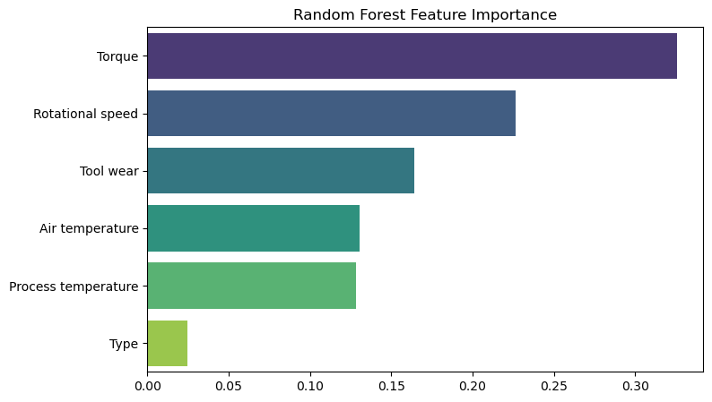

```python
def evaluate_model(y_true, y_pred, y_proba, model_name):
    print(f"\n {model_name} Results:")
    print("Accuracy :", accuracy_score(y_true, y_pred))
    print("Precision:", precision_score(y_true, y_pred))
    print("Recall   :", recall_score(y_true, y_pred))
    print("F1-score :", f1_score(y_true, y_pred))
    print("ROC-AUC  :", roc_auc_score(y_true, y_proba))
    print("\nClassification Report:\n", classification_report(y_true, y_pred))


    cm = confusion_matrix(y_true, y_pred)
    plt.figure(figsize=(5,4))
    sns.heatmap(cm, annot=True, fmt='d', cmap="Blues", xticklabels=["No Failure","Failure"], yticklabels=["No Failure","Failure"])
    plt.title(f"{model_name} Confusion Matrix")
    plt.xlabel("Predicted")
    plt.ylabel("Actual")
    plt.show()


evaluate_model(y_test, y_pred_lr, y_proba_lr, "Logistic Regression")
evaluate_model(y_test, y_pred_rf, y_proba_rf, "Random Forest")


feat_imp = pd.Series(rf.feature_importances_, index=X_processed.columns).sort_values(ascending=False)

plt.figure(figsize=(8,5))
sns.barplot(x=feat_imp, y=feat_imp.index, palette="viridis")
plt.title("Random Forest Feature Importance")
plt.show()
```

```python
from xgboost import XGBClassifier
from sklearn.model_selection import cross_val_score

# Initialize XGBoost
xgb_model = XGBClassifier(
    n_estimators=200,
    learning_rate=0.1,
    max_depth=6,
    subsample=0.8,
    colsample_bytree=0.8,
    random_state=42
)

xgb_scores = cross_val_score(xgb_model, X_train, y_train, cv=5, scoring='f1')

print("XGBoost Mean F1 Score:", xgb_scores.mean())

xgb_model.fit(X_train, y_train)
y_pred_xgb = xgb_model.predict(X_test)

print("XGBoost Test F1 Score:", f1_score(y_test, y_pred_xgb))
```

```
XGBoost Mean F1 Score: 0.7202579727327023
XGBoost Test F1 Score: 0.7478260869565218
```

```python
import pandas as pd
from sklearn.metrics import accuracy_score, precision_score, recall_score, f1_score, roc_auc_score

def evaluate_model(model, X_test, y_test, model_name):
    y_pred = model.predict(X_test)
    y_prob = model.predict_proba(X_test)[:, 1] if hasattr(model, "predict_proba") else None
    results = {
        "Model": model_name,
        "Accuracy": accuracy_score(y_test, y_pred),
        "Precision": precision_score(y_test, y_pred, zero_division=0),
        "Recall": recall_score(y_test, y_pred, zero_division=0),
        "F1 Score": f1_score(y_test, y_pred, zero_division=0),
        "ROC-AUC": roc_auc_score(y_test, y_prob) if y_prob is not None else "N/A"
    }
    return results

results = []
results.append(evaluate_model(log_reg, X_test, y_test, "Logistic Regression"))
results.append(evaluate_model(rf, X_test, y_test, "Random Forest"))
results.append(evaluate_model(xgb_model, X_test, y_test, "XGBoost"))

comparison_df = pd.DataFrame(results)
print(comparison_df)
```

```
                 Model  Accuracy  Precision    Recall  F1 Score   ROC-AUC
0  Logistic Regression    0.9680   0.666667  0.117647  0.200000  0.900476
1        Random Forest    0.9845   0.862745  0.647059  0.739496  0.964107
2              XGBoost    0.9855   0.914894  0.632353  0.747826  0.974676
```

## Classes are imbalenced .. lets fix it

```python
neg, pos = np.bincount(y_train)
scale_pos_weight = neg / pos
print("scale_pos_weight:", scale_pos_weight)


xgb_balanced = XGBClassifier(
    n_estimators=300,
    learning_rate=0.05,
    max_depth=6,
    subsample=0.8,
    colsample_bytree=0.8,
    eval_metric="logloss",
    scale_pos_weight=scale_pos_weight,
    random_state=42,
    use_label_encoder=False
)
xgb_balanced.fit(X_train, y_train)
y_pred_balanced = xgb_balanced.predict(X_test)

print("\nBalanced XGBoost Report:")
print(classification_report(y_test, y_pred_balanced))
print("F1 Score:", f1_score(y_test, y_pred_balanced, average="weighted"))
```

```
scale_pos_weight: 28.52029520295203
```

```
Balanced XGBoost Report:
              precision    recall  f1-score   support

           0       0.99      0.99      0.99      1932
           1       0.69      0.79      0.74        68

    accuracy                           0.98      2000
   macro avg       0.84      0.89      0.86      2000
weighted avg       0.98      0.98      0.98      2000

F1 Score: 0.9816260352169246
```

### I chose Logistic Regression as a simple, interpretable baseline model, Random Forest for its ability to handle complex feature interactions and improve detection accuracy, and XGBoost for its state-of-the-art performance, ability to manage imbalanced data, and provide explainability through feature importance. Together, these models balance interpretability and predictive power to effectively detect anomalies in the F&B manufacturing process.

## METRICS

```python
from sklearn.metrics import precision_recall_curve

y_prob = xgb_balanced.predict_proba(X_test)[:, 1]

threshold = 0.3
y_pred_thresh = (y_prob >= threshold).astype(int)

print("\nXGBoost with Threshold 0.3 Report:")
print(classification_report(y_test, y_pred_thresh))
print("F1 Score:", f1_score(y_test, y_pred_thresh, average="weighted"))

precisions, recalls, thresholds = precision_recall_curve(y_test, y_prob)
f1_scores = 2 * (precisions * recalls) / (precisions + recalls + 1e-6)

best_threshold = thresholds[np.argmax(f1_scores)]
print("\nBest Threshold based on F1:", best_threshold)
```

```
XGBoost with Threshold 0.3 Report:
              precision    recall  f1-score   support

           0       0.99      0.98      0.99      1932
           1       0.57      0.79      0.67        68

    accuracy                           0.97      2000
   macro avg       0.78      0.89      0.83      2000
weighted avg       0.98      0.97      0.98      2000

F1 Score: 0.9750752127844363

Best Threshold based on F1: 0.7767059
```

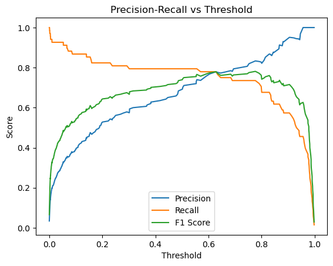

```python
plt.plot(thresholds, precisions[:-1], label="Precision")
plt.plot(thresholds, recalls[:-1], label="Recall")
plt.plot(thresholds, f1_scores[:-1], label="F1 Score")
plt.xlabel("Threshold")
plt.ylabel("Score")
plt.title("Precision-Recall vs Threshold")
plt.legend()
plt.show()
```

## FEATURE ATTRIBUTION

```python
!pip install shap
```

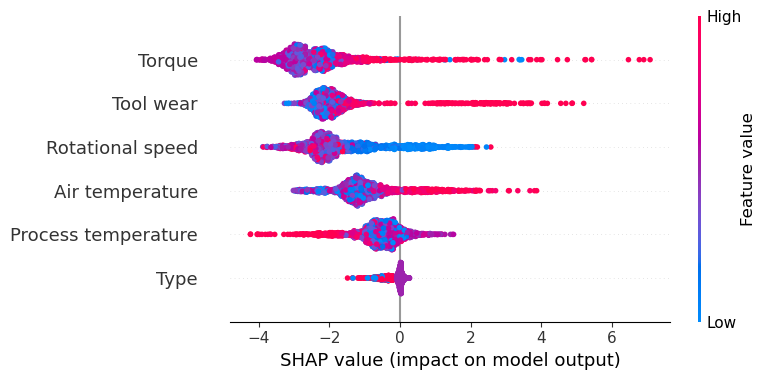

```python
import shap
explainer = shap.TreeExplainer(xgb_balanced)
shap_values = explainer.shap_values(X_test)
shap.summary_plot(shap_values, X_test)
```

```python
import joblib
joblib.dump(xgb_balanced, "anomaly_detector.pkl")
joblib.dump(scaler, "scaler.pkl")
```

```
['scaler.pkl']
```

```python
anomaly_scores = xgb_balanced.predict_proba(X_test)[:, 1] * 100
```

```python
df_results = X_test.copy()
df_results["true_label"] = y_test.values
df_results["anomaly_score"] = anomaly_scores

df_results["is_anomaly"] = (df_results["anomaly_score"] > 70).astype(int)
```

```python
top_features = []
for i in range(len(X_test)):
    feature_importances = dict(zip(X_test.columns, shap_values[i]))
    top_feature = max(feature_importances, key=lambda k: abs(feature_importances[k]))
    top_features.append(top_feature)
df_results["top_feature"] = top_features
```

## MODIFIES CSV WITH ANAMOLY SCORES AND TOP FEATURES

```python
df_results.to_csv("WITH_ANAMOLIES.csv", index=False)
print("Saved CSV with anomaly scores and top features...")
```

```
Saved CSV with anomaly scores and top features...
```

## VISUALIZATIONS

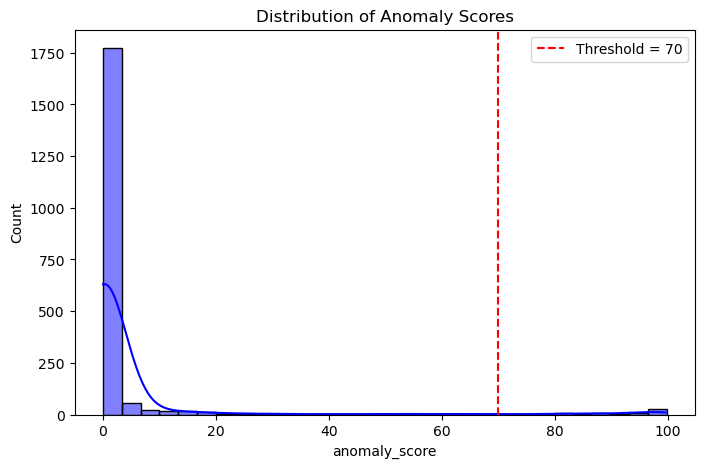

```python
plt.figure(figsize=(8,5))
sns.histplot(df_results["anomaly_score"], bins=30, kde=True, color="blue")
plt.axvline(70, color="red", linestyle="--", label="Threshold = 70")
plt.legend()
plt.title("Distribution of Anomaly Scores")
plt.show()
```

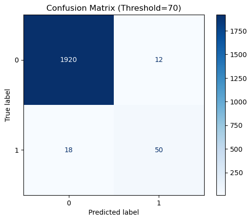

```python
from sklearn.metrics import confusion_matrix, ConfusionMatrixDisplay
cm = confusion_matrix(df_results["true_label"], df_results["is_anomaly"])
disp = ConfusionMatrixDisplay(confusion_matrix=cm)
disp.plot(cmap="Blues")
plt.title("Confusion Matrix (Threshold=70)")
plt.show()
```

```python
print("Total samples:", len(df_results))
print("Total anomalies detected:", df_results['is_anomaly'].sum())
print("\nTop 5 anomalies with highest scores:\n")
print(df_results.sort_values(by="anomaly_score", ascending=False).head())
```

```
Total samples: 2000
Total anomalies detected: 62

Top 5 anomalies with highest scores:

      Type  Air temperature  Process temperature  Rotational speed    Torque  \
6497     1         0.397503            -0.071148         -1.264961  2.539324
3935     2         1.297432             1.074667         -1.739093  2.830243
249      1        -1.002385            -1.149563         -0.746206  1.626443
9664     1        -0.452429             0.131054         -1.237071  1.486000
248      1        -1.002385            -1.149563         -0.986060  1.686633

      Tool wear  true_label  anomaly_score  is_anomaly top_feature
6497   1.320467           1      99.820290           1      Torque
3935   1.241914           1      99.715637           1      Torque
249    1.728945           1      99.634163           1   Tool wear
9664   1.933184           1      99.494476           1   Tool wear
248    1.697523           1      99.442848           1   Tool wear
```

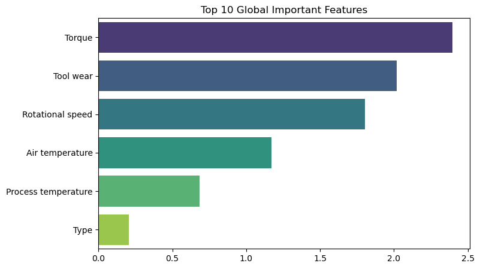

```python
importances = abs(shap_values).mean(axis=0)
feat_importance = pd.Series(importances, index=X_test.columns).sort_values(ascending=False)

plt.figure(figsize=(8,5))
sns.barplot(x=feat_importance[:10], y=feat_importance.index[:10], palette="viridis")
plt.title("Top 10 Global Important Features")
plt.show()
```

### The real-time visualization dashboard for this F&B process anomaly detection system would seamlessly display live sensor data like temperatures, mixer speed, torque, and tool wear as clear time-series graphs, allowing operators to monitor the production continuously. Alongside, an intuitive gauge would show the current anomaly score, instantly signaling whether the product quality is at risk, highlighted further by simple green or red indicators for normal or alert states. To help understand what's driving these predictions, the dashboard would also reveal the key process variables influencing quality using feature importance visualizations. Historical trends of anomalies, confusion matrices showing prediction accuracy, and correlations among variables would offer deeper insights over time, while interactive controls would let users zoom into specific batches or time periods for closer examination, empowering quality teams to catch issues early and maintain consistent product standards.

## Conclusion

#### This project has been more than just a technical task for me it’s been a journey of exploring how technology can genuinely create impact. Along the way, I faced challenges, made mistakes, refined my approach, and realized that even small improvements can lead to meaningful results.

#### What excites me most is not just the solution I built, but the possibilities it opens up. With more effort and consistent learning, I know this system can become smarter, faster, and more reliable.

#### For me, this work is a reminder that innovation isn’t about getting everything perfect in the first attempt. It’s about experimenting, adapting, and pushing to make things better step by step. This is just the start, and I’m looking forward to where it can go next.

# Thank You ~I.Pavan Santhosh